# Impact of Severe Weather Event in US

Thomas Yeung

April 29, 2017

## Synopsis

In this report we aim to describe the impact of severe weather events on public health and economic problems. This analysis used the data obtained from U.S. National Ocenaic and Atomospheric Adminstation’s (NOAA) storm database. This database tracks characteristics of major storms and weather events in the United States, including when and where they occur, as well as estimates of any fatalities, injuries, and property damage.From the data, we found that torando was the weather conditions that caused most fatalities and injuries in the U.S., with 5,633 cases and 91,346 cases respectively. For economic damaage, flood had the greatest damage with over 150 billion lost in $US.

### Data processing

First the dataset is downloaded from the sources and read into `fulldataset`.

```r
fileurl <- "https://d396qusza40orc.cloudfront.net/repdata%2Fdata%2FStormData.csv.bz2"
temp <- tempfile()
download.file (fileurl, temp) # save tge file into temp file
fulldataset <- read.csv(temp, na.strings = "NA")
unlink (temp) #unlink the temp file with the zip
rm (temp) # remove temp from the object list
```

Only the required varaiables are selected for the analysis in the next step. The variable list is obtained by the following

```r
variablelist <- names (fulldataset)
```

The the following is the full list of variables.

```
##  [1] "STATE__"    "BGN_DATE"   "BGN_TIME"   "TIME_ZONE"  "COUNTY"
##  [6] "COUNTYNAME" "STATE"      "EVTYPE"     "BGN_RANGE"  "BGN_AZI"
## [11] "BGN_LOCATI" "END_DATE"   "END_TIME"   "COUNTY_END" "COUNTYENDN"
## [16] "END_RANGE"  "END_AZI"    "END_LOCATI" "LENGTH"     "WIDTH"
## [21] "F"          "MAG"        "FATALITIES" "INJURIES"   "PROPDMG"
## [26] "PROPDMGEXP" "CROPDMG"    "CROPDMGEXP" "WFO"        "STATEOFFIC"
## [31] "ZONENAMES"  "LATITUDE"   "LONGITUDE"  "LATITUDE_E" "LONGITUDE_"
## [36] "REMARKS"    "REFNUM"
```

The requied varialbes are captured in the new variables of `selectedvariable`, and the following are the selected variables.

```r
selectedvariable <- variablelist[c(8, 23, 24, 25, 26, 27, 28)]
```

```
## [1] "EVTYPE"     "FATALITIES" "INJURIES"   "PROPDMG"    "PROPDMGEXP"
## [6] "CROPDMG"    "CROPDMGEXP"
```

The required `dataset` are subsetted from the full data set.

```r
dataset <- fulldataset[ ,c(selectedvariable)]
```

### Data transforming

To further analyze, the package of `dplyr` and `ggplot2` are loaded.

```r
library (ggplot2)
library (dplyr)
```

Before transforming, we check if there are cases of NA in the dataset.

```r
sapply (dataset, function(x) sum(is.na(x)))
```

```
##     EVTYPE FATALITIES   INJURIES    PROPDMG PROPDMGEXP    CROPDMG
##          0          0          0          0          0          0
## CROPDMGEXP
##          0
```

There are no NA cases in any of the variables, thus, we can transform the data directly. We first converting the actual lost / damanage in money term. The actual property damanage is `ACTPROPDMG` and the actual crop damage is `ACTCROPDMG`. We then calculate the total damanage by summing up these two variables in `TOTALDMG`.

```r
#calacuate the exact number of property damange
dataset <- dataset %>% mutate (ACTPROPDMG = ifelse (
        PROPDMGEXP == "K", PROPDMG*1000, ifelse (
                PROPDMGEXP == "m" | PROPDMGEXP == "M", PROPDMG*1000000, ifelse(
                        PROPDMGEXP == "B", PROPDMG*1000000000, ifelse (
                                PROPDMGEXP =="h" | PROPDMGEXP =="H", PROPDMG*100, PROPDMG)
                )
        )
))

#calculate the exact number of crop damage
dataset <- dataset %>% mutate (ACTCROPDMG = ifelse (
        CROPDMGEXP == "K" | CROPDMGEXP == "k", CROPDMG*1000, ifelse (
                CROPDMGEXP == "M" | CROPDMGEXP == "m", CROPDMG*1000000, ifelse(
                        CROPDMGEXP == "B", CROPDMG*1000000000, CROPDMG
                )
        )
)  )

#calculate the total damage
dataset <- dataset %>% mutate (TOTALDMG = ACTPROPDMG + ACTCROPDMG)
```

### Fatalities

The total fatalities cases of all kinds of severe weather conditions are calculated.

```r
fatalities <- dataset %>% group_by (EVTYPE) %>% summarize (FATALITIES = sum(FATALITIES))
fatalities <- fatalities %>% arrange (desc(FATALITIES))
```

The following table shows the top 5 conditions with the most fatalities cases with the following graph

```
## # A tibble: 5 × 2
##           EVTYPE FATALITIES
##           <fctr>      <dbl>
## 1        TORNADO       5633
## 2 EXCESSIVE HEAT       1903
## 3    FLASH FLOOD        978
## 4           HEAT        937
## 5      LIGHTNING        816
```

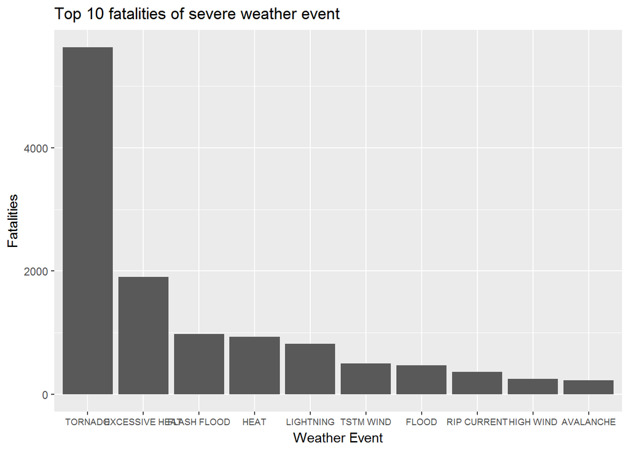

```r
ggplot (data = head (fatalities, 10),
        aes(x=reorder(EVTYPE, -FATALITIES), y=FATALITIES))+
        geom_bar(stat = "identity")+
        xlab("Weather Event")+ylab("Fatalities")+
        theme(axis.text.x = element_text(size = 7))+
        ggtitle("Top 10 fatalities of severe weather event")
```

From the above analysis, tornado is the weather condition that caused most of the fatal cases.

### Injuries

The total injuries cases of all kind of severe weather conditions are calculated.

```r
injuries <- dataset %>% group_by (EVTYPE) %>% summarize (INJURIES = sum (INJURIES))
injuries <- injuries %>% arrange (desc (INJURIES))
```

The following table shows the top 5 conditions with the most injuries cases with the following graph.

```
## # A tibble: 5 × 2
##           EVTYPE INJURIES
##           <fctr>    <dbl>
## 1        TORNADO    91346
## 2      TSTM WIND     6957
## 3          FLOOD     6789
## 4 EXCESSIVE HEAT     6525
## 5      LIGHTNING     5230
```

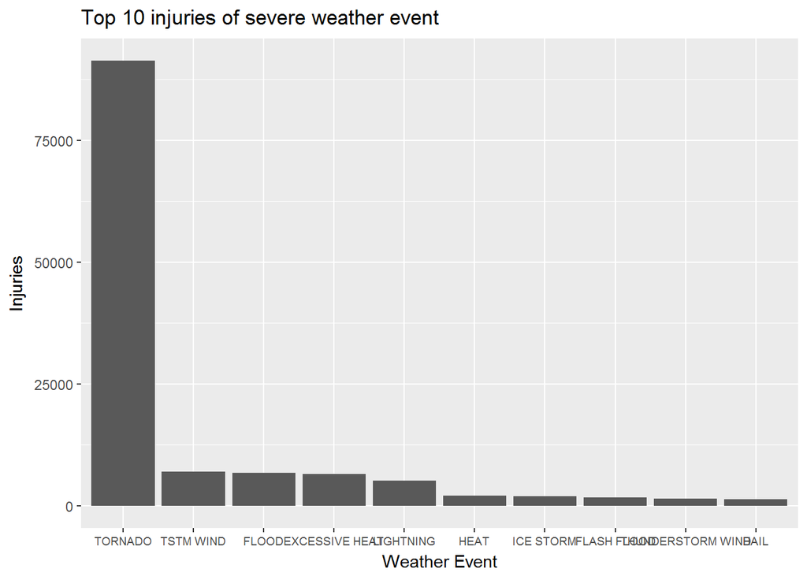

```r
ggplot (data = head (injuries, 10),
        aes(x=reorder(EVTYPE, -INJURIES), y=INJURIES))+
        geom_bar(stat = "identity")+
        xlab("Weather Event")+ylab("Injuries")+
        theme(axis.text.x = element_text(size = 7))+
        ggtitle("Top 10 injuries of severe weather event")
```

### Economic damanage

In terms of economic damage, we combine the data of property damage and crop damage. The analysis is based on the total lost of US dollars of both kind of damage.

```r
totaldmg <- dataset %>% group_by (EVTYPE) %>% summarize (TOTALDMG = sum(TOTALDMG))
totaldmg <- totaldmg %>% arrange (desc (TOTALDMG))
```

The following table shows the top 5 conditions with the most economic damage in USD, with the graph

```
## # A tibble: 5 × 2
##              EVTYPE     TOTALDMG
##              <fctr>        <dbl>
## 1             FLOOD 150319678257
## 2 HURRICANE/TYPHOON  71913712800
## 3           TORNADO  57352114049
## 4       STORM SURGE  43323541000
## 5              HAIL  18758222016
```

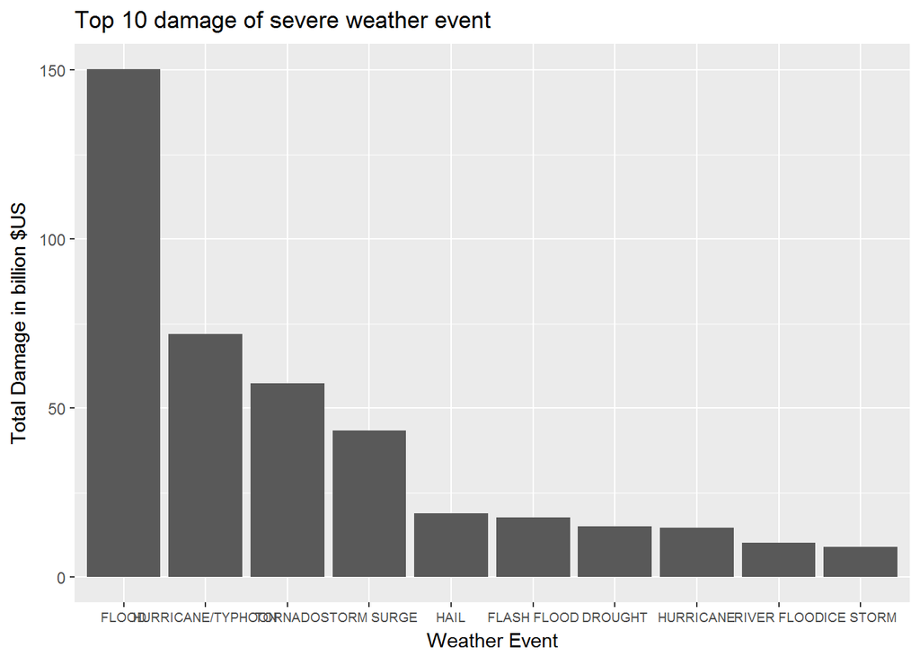

```r
ggplot (data = head (totaldmg, 10),
        aes (x=reorder(EVTYPE, -TOTALDMG), y=TOTALDMG/1000000000))+
        geom_bar(stat = "identity")+
        xlab("Weather Event") + ylab ("Total Damage in billion $US")+
        theme (axis.text.x = element_text(size = 7))+
        ggtitle ("Top 10 damage of severe weather event")
```

From the above graph, flood create the most economic damage, and it is 2.0902784 than the second most condition, Hurricane.